# Лабораторная работа 1

Сопова Екатерина, Ри-450004

20 сентября 2018 ?

# Задание 1

1)Сгенерировать 200 случайных значений из стандартного экспоненциального распределения и сохранить в вектор exp.1. Найти среднее и стандартное отклонение из данных этого вектора..

$\lambda = 1$

```r
exp.1<-rexp(200)
exp.1.mean<-mean(exp.1)
exp.1.mean
```

```
## [1] 1.046462
```

```r
exp.1.sd<-sd(exp.1)
exp.1.sd
```

```
## [1] 1.077215
```

2)Повторить, использовав следующие значения параметра λ= 0.1, 0.5, 5, 10, и сохранить результаты в векторы: exp.0.1, exp.0.5, exp.5, exp.10.

$\lambda = 0.1$

```r
exp.0.1<-rexp(200, 0.1)
exp.0.1.mean<-mean(exp.0.1)
exp.0.1.sd<-sd(exp.0.1)
```

$\lambda = 0.5$

```r
exp.0.5<-rexp(200, 0.5)
exp.0.5.mean<-mean(exp.0.5)
exp.0.5.sd<-sd(exp.0.5)
```

$\lambda = 5$

```r
exp.5<-rexp(200, 5)
exp.5.mean<-mean(exp.5)
exp.5.sd<-sd(exp.5)
```

$\lambda = 10$

```r
exp.10<-rexp(200, 10)
exp.10.mean<-mean(exp.10)
exp.10.sd<-sd(exp.10)
```

3)Используя функцию hist(), построить гистограмму полученного ранее стандартного распределения.

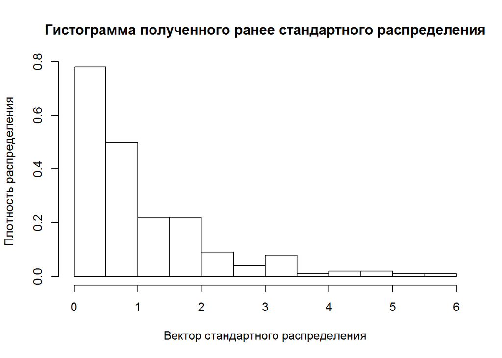

```r
hist(exp.1, prob = TRUE, main = "Гистограмма полученного ранее стандартного распределения",  ylab = "Плотность распределения", xlab = "Вектор стандартного распределения")
```

4)Используя функцию plot() с тем же самым вектором для построения графика значений в порядке следования.

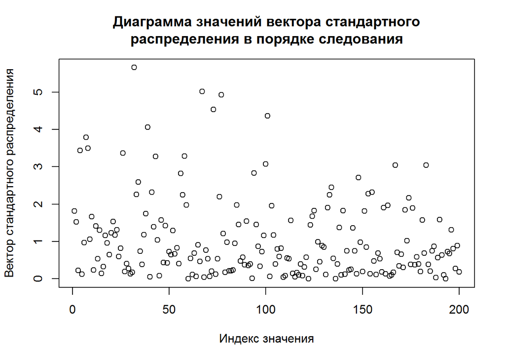

```r
plot(exp.1, xlab="Индекс значения", ylab = "Вектор стандартного распределения", main="Диаграмма значений вектора стандартного\nраспределения в порядке следования")
```

5)Используя функцию plot() с любыми двумя полученными ранее векторами, чтобы получить диаграмму рассеяния (scatterplot) этих векторов относительно друг друга.

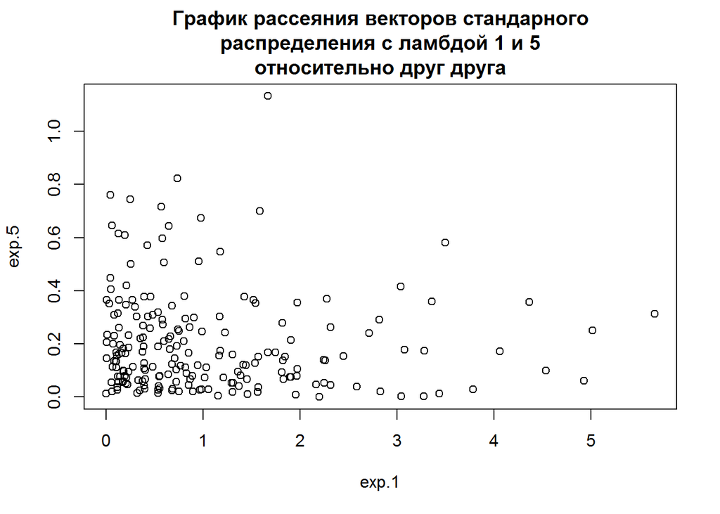

```r
plot(exp.1, exp.5, main = "График рассеяния векторов стандарного\nраспределения с ламбдой 1 и 5\nотносительно друг друга")
```

6)Теперь сравним свойства всех наших векторов. Для начала создадим вектор, содержащий средние значения каждого из 5 полученных ранее распределений в порядке их создания. Полученный вектор сохраним в переменную exp.means.

```r
exp.means<-c(exp.1.mean,exp.0.1.mean,exp.0.5.mean,exp.5.mean,exp.10.mean)
exp.value<-c(1, 0.1, 0.5, 5, 10)
exp.sds<-c(exp.1.sd,exp.0.1.sd,exp.0.5.sd,exp.5.sd,exp.10.sd)
```

7)Создать следующие диаграммы рассеяния:

Вектор с пятью средними относительно каждого из пяти векторов с различными значениями $\lambda$

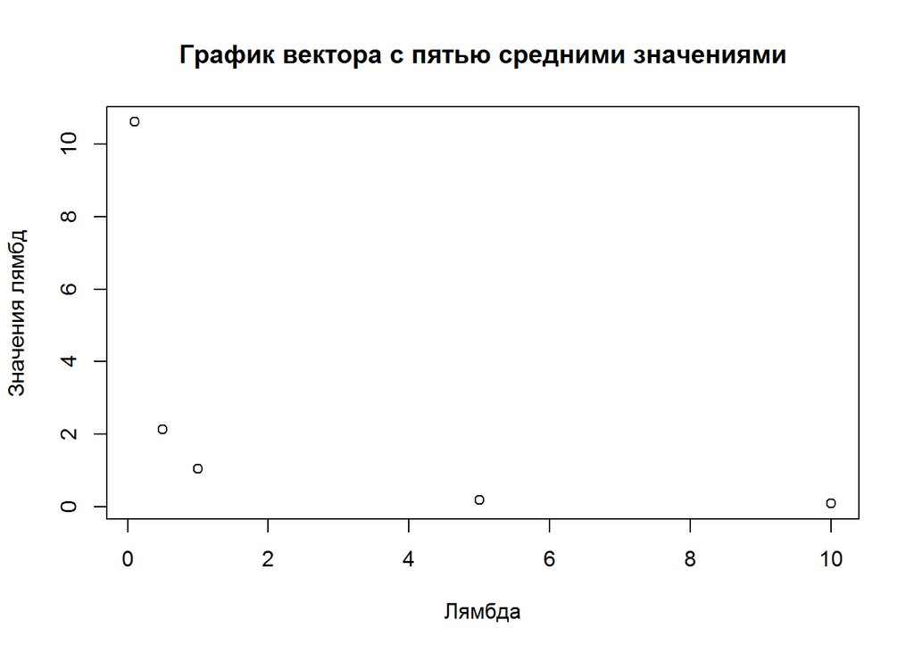

```r
plot(exp.value, exp.means,main = "График вектора с пятью средними значениями",xlab = "Лямбда", ylab = "Значения лямбд")
```

8)Вектор с пятью стандартными отклонениями относительно каждого из пяти векторов с различными значениями $\lambda$

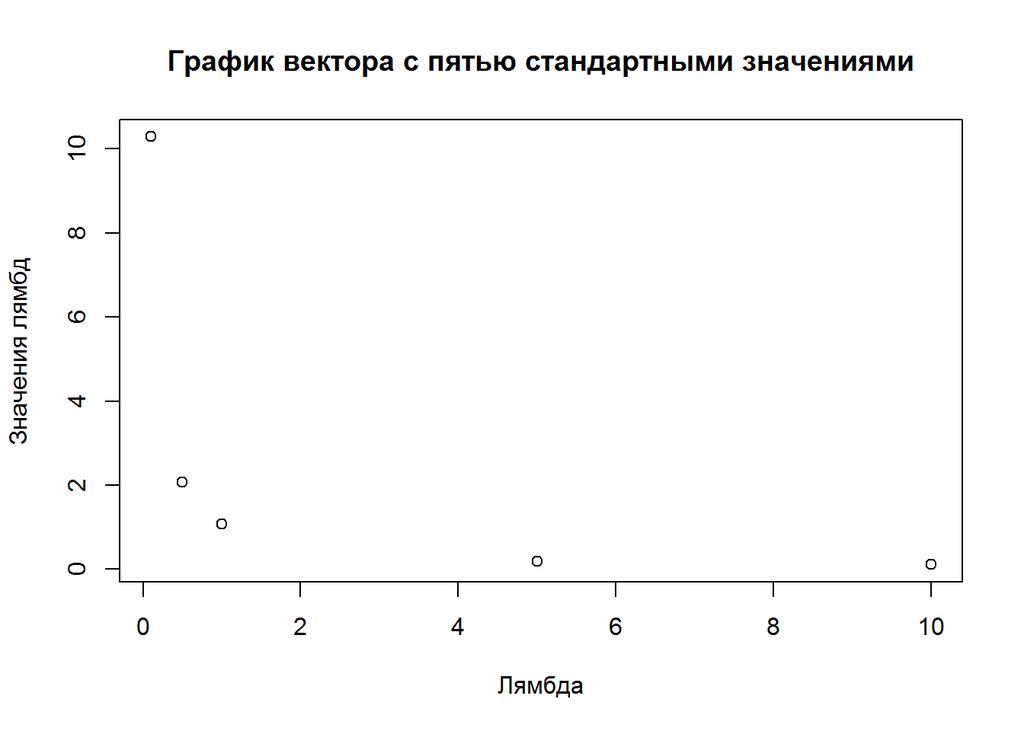

```r
plot(exp.value, exp.sds,main = "График вектора с пятью стандартными значениями",xlab = "Лямбда", ylab = "Значения лямбд")
```

9)Вектор с пятью средними относительно вектора с пятью стандартными отклонениями.

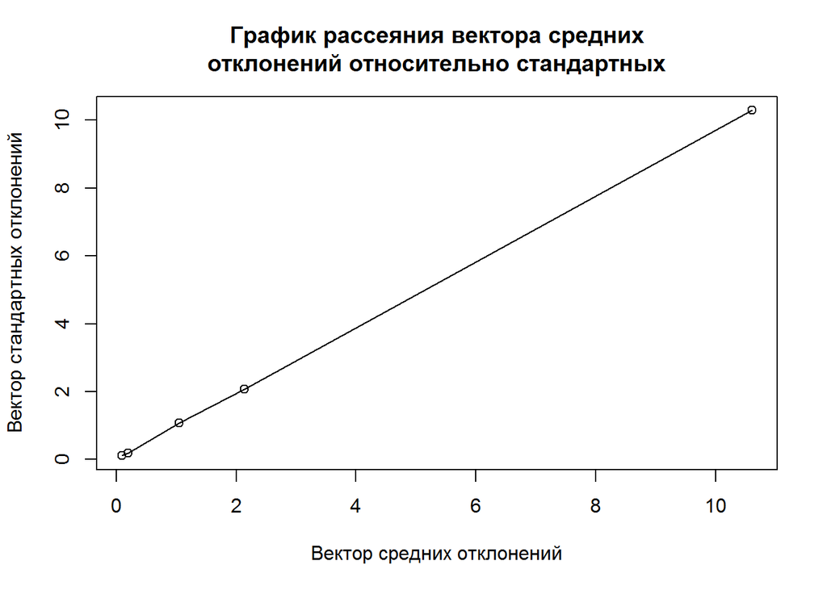

```r
plot(exp.means,exp.sds,main = "График рассеяния вектора средних\nотклонений относительно стандартных",xlab = "Вектор средних отклонений", ylab = "Вектор стандартных отклонений")
lines(exp.means[order(exp.means)],exp.sds[order(exp.means)])
```

# Задание 2

1)Сгенерировать 1100000 (1 млн. 100 тысяч) чисел из стандартного экспоненциального распределения и сохранить их в вектор huge.exp.1. Получить среднее и стандартное отклонение.

```r
huge.exp.1=rexp(1100000)
huge.exp.1.mean<-mean(exp.1)
huge.exp.1.sd<-sd(exp.1)
```

2)Построить гистограмму huge.exp.1. Она соответствует функции $F(x) = 1 - e^{-\lambda x}$ Должна ли?

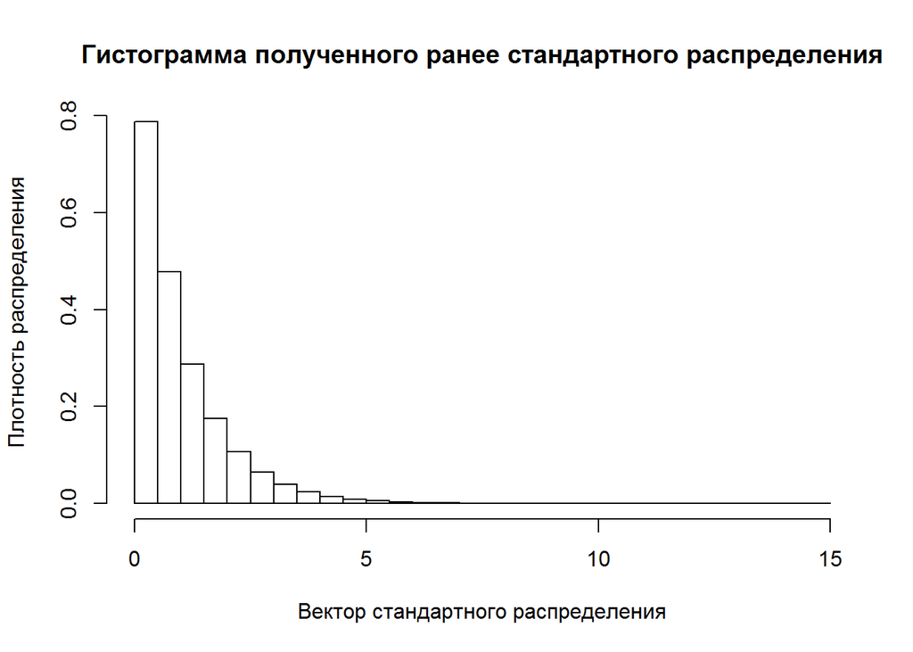

```r
hist(huge.exp.1,  main = "Гистограмма полученного ранее стандартного распределения",   prob = TRUE, ylab = "Плотность распределения", xlab = "Вектор стандартного распределения")
```

Как видно из гистограммы, плотность вероятности не соответствует функции распределения $1 - e^{-x}$.

3)Получить среднее всех чисел из huge.exp.1 строго больших 1. Для проверки выборки может потребоваться новый вектор.

```r
huge.exp.1.more.than.1<-mean(huge.exp.1>1)
huge.exp.1.more.than.1
```

```
## [1] 0.3674945
```

4)Получить матрицу huge.exp.1.mat, содержащую 1100 строк и 1000 колонок. Построить гистограмму, использовав полученную матрицу. Что можно сказать о полученных данных?

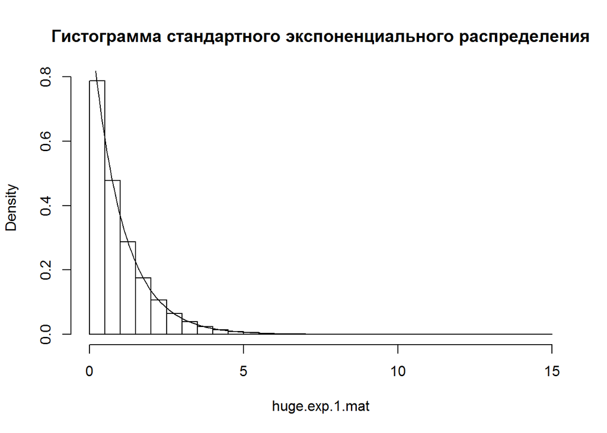

```r
huge.exp.1.mat<-matrix(huge.exp.1, nrow=1100, ncol=1000)
hist(huge.exp.1.mat, prob = TRUE, main = "Гистограмма стандартного экспоненциального распределения")
curve(dexp(x), from = 0, to = 8, add = TRUE)
```

Вторая гистограмма визуально похожа на первую, из чего следует, что вид гистограммы не зависит от способа представления входных данных.

Рассчитайть среднее 137-й колонки из huge.exp.1.mat.

```r
colMeans(huge.exp.1.mat)[137]
```

```
## [1] 0.9595246
```

6)Найти среднее всех 1000 колонок и сохраните их в вектор. Отобразить диаграмму средних зннчений колонок. Объясните почему форма диаграммы отличается от виденных ранее.

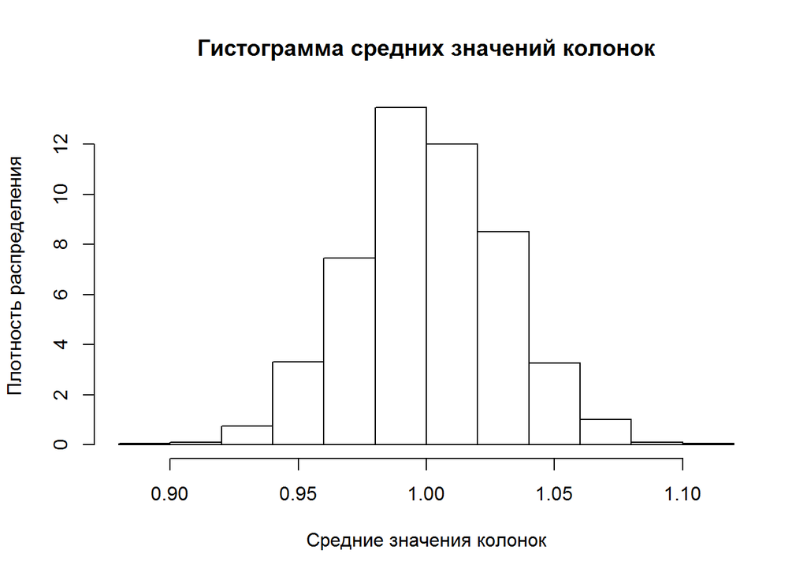

```r
huge.exp.1.colmeans<-colMeans(huge.exp.1.mat)
hist(huge.exp.1.colmeans, prob = TRUE, main = "Гистограмма средних значений колонок", ylab="Плотность распределения", xlab="Средние значения колонок")
```

Гистограмма отличается от двух выше приведенных потому, что среднее експотациональное распределение равно 1/$\lambda$ и так как в этом случае $\lambda$=1 и поэтому среднее значение каждой калонке стремится к единице. Что мы можем увидеть на гистрограмме.

7)Рассчитать квадрат каждого значения из huge.exp.1 и найти среднее и стандартное отклонение полученного вектора квадратов. Объяснить отличие от соответствующих показателей вектора huge.exp.1. Вам может помочь формула, по которой R рассчитывает стандартное отклонение: $\sqrt{\frac{\sum{(x - M(x))^2}} {n - 1}}$.

```r
huge.exp.1.square<-huge.exp.1^2
huge.exp.1.square.mean<-mean(huge.exp.1.square)
huge.exp.1.square.sd<-sd(huge.exp.1.square)
huge.exp.1.square.mean/huge.exp.1.mean
```

```
## [1] 1.914587
```

```r
huge.exp.1.square.sd/huge.exp.1.sd
```

```
## [1] 4.160847
```

Среднее значение экспотационального распределения равняется 1/$\lambda$, а в даном случае $\lambda$ = 1. При распределении квадратов исходное значение среднего экпотационального значение увеличилось почти в два раза. Стандартное отклонение тоже увеличилось, но тут увеличение было больше чемв два раза. Это связано с тем что в форумле стандартного отклонения присутствует не только арифмитические действия с исходными данными, но и возведение в квадрат.